# Lab 4

Erica Bishop

2023-05-09

Lab 4 Assignment: Due May 9 at 11:59pm

```r
urlfile ="https://raw.githubusercontent.com/MaRo406/EDS-231-text-sentiment/main/data/climbing_reports_model_dat.csv"
incidents_df<-readr::read_csv(url(urlfile))
```

### 1. Select another classification algorithm

I’ll use a support vector machine classification model becuase SVM’s are efficient where there are a lot of featuers (i.e. a lot of tokens - as in this text analysis).

### 2. Conduct an initial out-of-the-box model fit on the training data and prediction on the test test data. Assess the performance of this initial model.

```r
#set seed for reproducibility
set.seed(567)

#transform data so category is two classes
incidents2class <- incidents_df %>%
  mutate(fatal = factor(if_else(is.na(Deadly),
                                "non-fatal",
                                "fatal")))

#split data to train model
incidents_split <- initial_split(incidents2class)

incidents_train <- training(incidents_split)
incidents_test <- testing(incidents_split)
```

```r
#set recipe
recipe <- recipe(fatal ~ Text,
       data = incidents_train) %>%
  step_tokenize(Text) %>% #turning each word in text into a different feature
  step_tokenfilter(Text, max_tokens = 1000) %>%  #max_tokens argument limits to just most frequent words (number of features you want)
  step_tfidf(Text) #term frequency individual document frequency takes into account tfdf metric


#use default engine and tuning parameters
svm_spec <- svm_rbf() %>%
  set_engine("kernlab") %>%
  set_mode("classification") # %>%
# translate()
# might have to use 'translate'

#bundle into a workflow
svm_wf <- workflow() %>%
  add_recipe(recipe) %>%
  add_model(svm_spec)
```

```r
svm_fit <- svm_wf %>%
  fit(data = incidents_train)
```

```r
#resampling because relatively small dataset
#use default 10-fold cross validation
incidents_fold <- vfold_cv(incidents_train)

#fit data to resamples
svm_rs_fit <- fit_resamples(
  svm_wf,
  incidents_fold,
  control = control_resamples(save_pred = T)
)
```

```r
svm_rs_metrics <- collect_metrics(svm_rs_fit)
svm_rs_predictions <- collect_predictions(svm_rs_fit)

#print out a cute table
gt::gt(svm_rs_metrics,
       caption = "SVM model performance with 10-fold cross validation")
```

SVM model performance with 10-fold cross validation

| .metric | .estimator | mean | n | std_err | .config |
| --- | --- | --- | --- | --- | --- |
| accuracy | binary | 0.8599080 | 10 | 0.011431813 | Preprocessor1_Model1 |
| roc_auc | binary | 0.9352783 | 10 | 0.006439085 | Preprocessor1_Model1 |

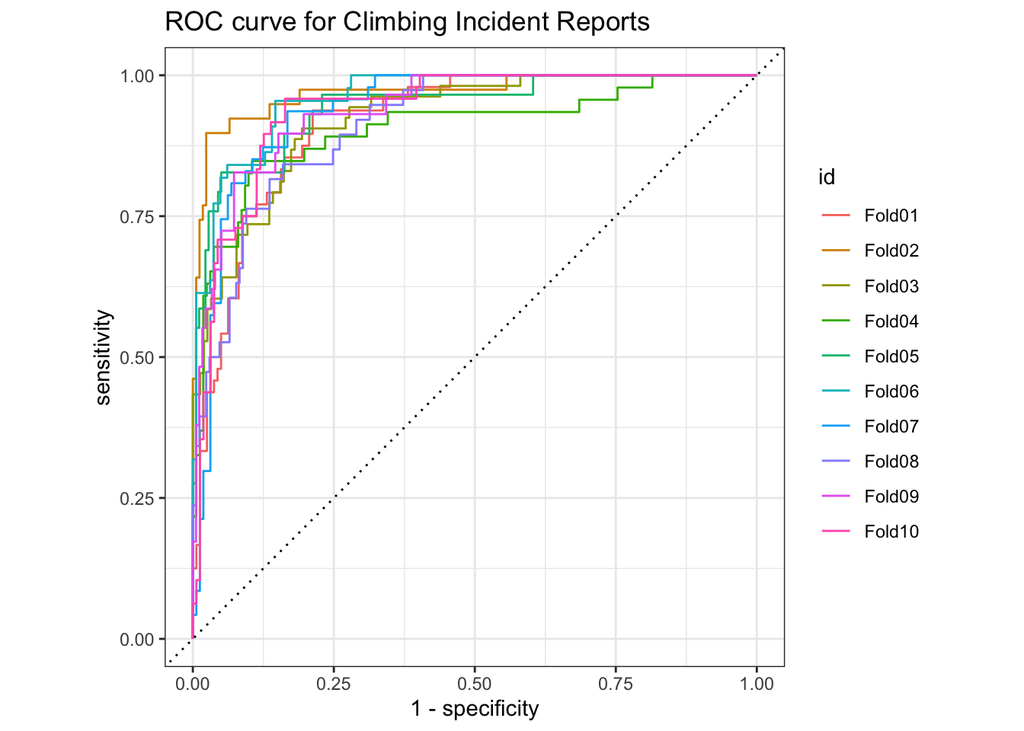

```r
svm_rs_predictions |>
  group_by(id) |>
  roc_curve(truth = fatal, .pred_fatal) |>
  autoplot() +
  labs("Resamples",
       title = "ROC curve for Climbing Incident Reports")
```

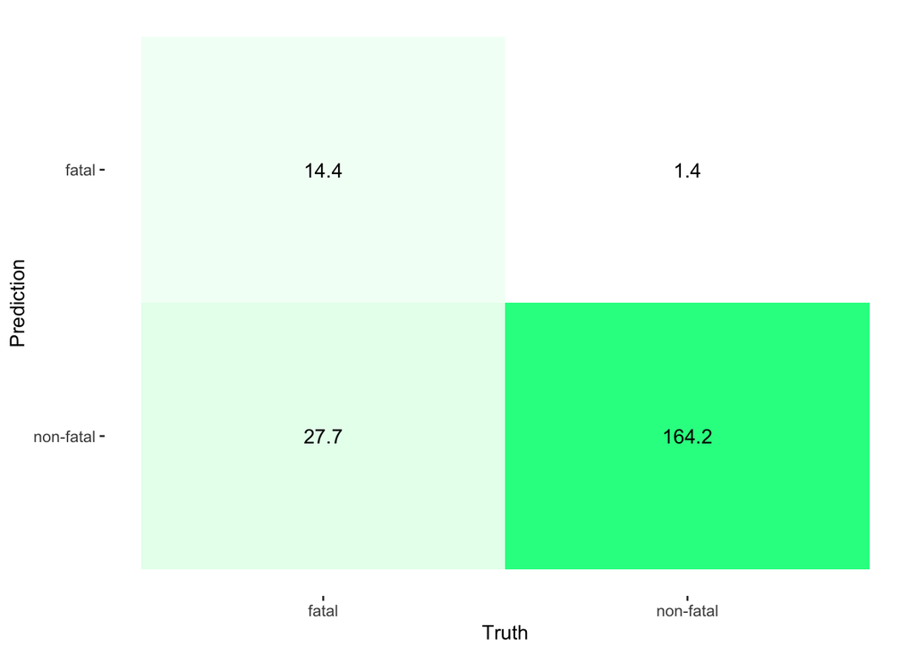

```r
conf_mat_resampled(svm_rs_fit, tidy = FALSE) |>
  autoplot(type = "heatmap") +
scale_fill_gradient(low = "#ffffff", high = "#1cfc90")
```